# **Lab Assignment 4**

### Name : Garvita Jain , 1229516446

### You must use this provided framework as-is and follow all the directions stated in there:

- Do NOT edit or otherwise change any part of this framework except the cells you have been instructed to code.
- You must NOT import any additional python packages to complete this assignment

### Note that, points will be deducted for notebooks that:

- do not follow the saving guidelines/naming convention
- do not compile/run
- do not follow all the instructions in the framework
- are incomplete
- have logical errors
- don’t result in the expected output

## Exercise 1 (Gradient Descent)

- In this assignment, you will first use the gradient descent algorithm to find the optimal value of w1 which minimizes the given lost function (Steps 1.1 through 1.5). You will earn 5% points for each step and 25% in total.
- You will run the algorithm for 4 different scenarios, each with a different value of alpha. For each scenario, you will log the responses in the last cell of this notebook (Step 1.6). You will earn 5% points for each scenario and 20% in total.

```python
# DO NOT edit this cell!
# You must use this lost function and its derivative as-is

# lost at particular value of w1
def calc_J(w1):
    return (5.5*w1*w1 - 1463*w1 + 100812.5)

# slope at particular value of w1
def calc_dJ_dw1(w1):
    return (11*w1 - 1463)
```

```python
# First, complete coding Steps 1.1 through 1.5 in this cell.
# Then, run this cell for each of the four scenarios below,
# and log your responses for each scenario run in the next cell (Step 1.6)
# alpha=0.08; niterations = 25; w1 = 60 # Scenario 1
# alpha=0.05; niterations = 25; w1 = 60 # Scenario 2
# alpha=0.15; niterations = 25; w1 = 60 # Scenario 3
alpha=0.19; niterations = 25; w1 = 60 # Scenario 4

# Step 1.1: calculate current value of J at current value of w1
current_J = calc_J(w1)
print(f"Initial w1: {w1:.2f}, Initial J: {current_J:.2f}")


# Step 1.2: print w1 (rounded to 2 decimal places) and J (rounded to 2 decimal places)
# your code here


# run gradient descent for niterations
for i in range(niterations):

    # Step 1.3: calculate new value of w1
    w1 = w1 - alpha * calc_dJ_dw1(w1)


    # Step 1.4: calculate new value of J at new w1
    new_J = calc_J(w1)


    # Step 1.5: print w1 (rounded to 2 decimal places) and J (rounded to 2 decimal places)
    print(f"Iteration {i+1}: w1 = {w1:.2f}, J = {new_J:.2f}")
```

```
Initial w1: 60.00, Initial J: 32832.50
Iteration 1: w1 = 212.57, J = 38345.62
Iteration 2: w1 = 46.27, J = 44895.75
Iteration 3: w1 = 227.54, J = 52677.97
Iteration 4: w1 = 29.95, J = 61924.01
Iteration 5: w1 = 245.32, J = 72909.25
Iteration 6: w1 = 10.57, J = 85960.80
Iteration 7: w1 = 266.45, J = 101467.35
Iteration 8: w1 = -12.46, J = 119890.68
Iteration 9: w1 = 291.55, J = 141779.44
Iteration 10: w1 = -39.82, J = 167785.48
Iteration 11: w1 = 321.37, J = 198683.25
Iteration 12: w1 = -72.32, J = 235392.89
Iteration 13: w1 = 356.80, J = 279007.62
Iteration 14: w1 = -110.95, J = 330826.28
Iteration 15: w1 = 398.90, J = 392392.02
Iteration 16: w1 = -156.83, J = 465538.29
Iteration 17: w1 = 448.92, J = 552443.36
Iteration 18: w1 = -211.35, J = 655695.28
Iteration 19: w1 = 508.34, J = 778368.89
Iteration 20: w1 = -276.12, J = 924117.40
Iteration 21: w1 = 578.94, J = 1097281.20
Iteration 22: w1 = -353.08, J = 1303017.12
Iteration 23: w1 = 662.82, J = 1547451.97
Iteration 24: w1 = -444.51, J = 1837865.00
Iteration 25: w1 = 762.48, J = 2182904.73
```

```python
# Step 1.6: for each Scenario, answer the following questions based on the output (20%)
# type your answers below for each question
#
### Scenario 1 (alpha=0.08; niterations = 25; w1 = 60):
# Did the cost steadily decrease as training progressed?
# Yes, the cost steadily decreased as training progressed. Starting from an initial cost of 32832.50, it rapidly dropped to 3945.06 by the first iteration and continued to decrease until it reached 3523.00 by the fourth iteration, after which it remained constant.

# Did the gradient descent algorithm converge?
# Yes, the gradient descent algorithm converged. The value of w1 stabilized at 133.00, and the cost function value stabilized at 3523.00, indicating convergence.

# What is the minimum lost?
# The minimum loss (cost) achieved is 3523.00. This value remained constant from the fourth iteration onwards, indicating that the minimum was reached.

# What is the optimal value of w1?
# The optimal value of w1 is 133.00. This value was achieved by the fourth iteration and remained stable throughout the rest of the training process.

# In how many iterations did gradient descent converge (at which row # in the output)?
# The gradient descent algorithm effectively converged by the fourth iteration, as indicated by the stabilization of both w1 and the cost at their respective values. Therefore, convergence occurred at row #4 in the output.
#







### Scenario 2 (alpha=0.05; niterations = 25; w1 = 60):
# Did the cost steadily decrease as training progressed?
# Yes, the cost steadily decreased as training progressed. This is evident from the initial cost of 32832.50 decreasing significantly by the first iteration and continuing to decrease until it stabilizes around 3523.00 from iteration 10 onwards.

# Did the gradient descent algorithm converge?
# Yes, the gradient descent algorithm converged. The values of w1 and the cost �
# J stabilize at 133.00 and 3523.00, respectively, indicating convergence.

# What is the minimum lost?
# The minimum loss observed in this scenario is 3523.00.

# What is the optimal value of w1?
# The optimal value of w1 at which the minimum loss is achieved is 133.00.

# In how many iterations did gradient descent converge (at which row # in the output)?
# The gradient descent algorithm effectively converged by iteration 10 (row #11 in the output), where the cost reaches 3523.00 and remains stable thereafter. This suggests that any further iterations beyond this point do not significantly change the value of
# w1 or reduce the cost, indicating convergence.









### Scenario 3 (alpha=0.15; niterations = 25; w1 = 60):

# Did the cost steadily decrease as training progressed?
# Yes, the cost (value ofJ) steadily decreased as the training progressed. Starting from an initial cost of 32832.50, it consistently went down with each iteration, indicating that the algorithm was successfully moving towards the minimum of the loss function.

# Did the gradient descent algorithm converge?
# Yes, the gradient descent algorithm converged. This is evident from the fact that the changes in w1 and J and J became very small in the last few iterations, indicating that further updates were not significantly reducing the cost. The values stabilized around w1 =133.00 and
# J=3523.00.

# What is the minimum lost?
# The minimum loss observed in the output is
# 3523.00
# 3523.00. This value represents the lowest point reached by the algorithm within the given iterations and starting conditions.

# What is the optimal value of w1 ?
# The optimal value of w1, as found by the algorithm, is approximately 133.00. This is the value of w1 at which the loss function J(w1) reached its minimum within the constraints of the experiment.

# In how many iterations did gradient descent converge (at which row # in the output)?
# To determine convergence, we look for the point at which further iterations cease to produce significant changes in the value of w1 and J. While the definition of "converge" can vary based on the threshold set for significant change, looking at the output, we can see that by iteration 19 (w1 =133.02,J=3523.00) and onwards, changes become negligible, suggesting convergence around this point. Thus, we could consider iteration 19 as the point of convergence for practical purposes, as further iterations do not significantly alter the values.

#
### Scenario 4 (alpha=0.19; niterations = 25; w1 = 60):


# Did the cost steadily decrease as training progressed?
# No, the cost did not steadily decrease. It actually increased with each iteration, indicating that the gradient descent algorithm is moving away from the minimum of the cost function rather than converging towards it.
# Did the gradient descent algorithm converge?
# The gradient descent algorithm did not converge to a minimum within the given 25 iterations. Instead, the values of w1
#   oscillated significantly, and the cost increased, indicating divergence rather than convergence.
# What is the minimum lost?
# Based on the provided output, the algorithm did not find a minimum within the 25 iterations. The cost continuously increased, reaching a maximum value of 2,182,904.73 by the 25th iteration, which is far from a minimum.
# What is the optimal value of w1?
# The algorithm did not converge to an optimal value of w1 . Instead,w1  values oscillated and diverged away from any potential minimum, ending at 762.48 in iteration 25, which is not indicative of an optimal value.
# In how many iterations did gradient descent converge (at which row # in the output)?
# Gradient descent did not converge within the provided 25 iterations. There's no row number in the output where convergence is observed; instead, the algorithm exhibits a divergent behavior throughout all iterations.
```

**Scenario 1:**

**Scenario 2:**

**Scenario 3:**

**Scenario 4:**

1. Did the cost steadily decrease as training progressed?
- No, the price did not go down gradually. In actuality, it rose noticeably as training went on. This shows that the algorithm has exceed the minimum due to an excessively high learning rate.
1. Did the gradient descent algorithm converge?

-In this case, the gradient descent algorithm did not converge. Divergence rather than convergence is indicated by the substantial variations and overall increasing trend in the values of w1 and the cost.

1. What is the minimum cost?
- The minimum cost is not clearly identifiable in this scenario, as the algorithm did not converge and the cost kept increasing. The initial cost was 32832.50, but it increased substantially after that.
1. What is the optimal value of w1?
- An optimal value of w1 cannot be determined from this scenario.
1. In how many iterations did gradient descent converge (at which row # in the output)?
- In this scenario, the gradient descent did not converge within the given 25 iterations. The algorithm shows signs of divergence with the cost and w1 values escalating drastically.

## Exercise 2 (Single Neuron)

### Then, you will apply deep learning thinking in modeling a single neuron to build logistic regression and linear regression models. You need also to Apply the idea of vectorization to efficiently train your models and implement gradient descent from scratch (using multiple iterations of the forward pass, backward propagation, and gradient descent steps) to minimize the loss functions and determine model parameters.

### Specifically, there are two parts in this assignment:

- In the first part, you will train a logistic regression model using the breast cancer data set. This part has 7 parts (2.1.1 through 2.1.7) that you will need to code (see framework for more details).
- In the second part, you will train a linear regression model using the diabetes data set. This part has 7 parts (2.2.1 through 2.2.7) that you will need to code (see framework for more details).

```python
### DO NOT EDIT THIS CELL!!!
### DO NOT IMPORT ANY ADDITIONAL PACKAGES

import numpy as np
import scipy
from sklearn import metrics
import matplotlib.pyplot as plt
%matplotlib inline
```

### PART 1

- Logistic Regression for Binary Classification using the breast cancer dataset
- We aren't going to preprocess data or split into train/test since the focus here is purely on the gradient descent algorithm
- NOTE: YOU WILL ONLY EDIT ONE CELL FOR PART-1 (SEE BELOW) (5% for each step, but 25% in total)

```python
### DO NOT EDIT THIS CELL!!!

# read the breast cancer dataset from sklearn
from sklearn.datasets import load_breast_cancer

dataset = load_breast_cancer()

# feature matrix X: mxn
X = dataset.data
print ("X: ", X.shape)

# target vector y: mx1
y = dataset.target
y = y.reshape(y.shape[0], 1)
print ("y: ", y.shape)

# number of samples: m
m = X.shape[0]
print ("m: ", m)

# number of features: n
n = X.shape[1]
features = dataset.feature_names
print ("n: ",n)
print ("features: ", features)
```

```
X:  (569, 30)
y:  (569, 1)
m:  569
n:  30
features:  ['mean radius' 'mean texture' 'mean perimeter' 'mean area'
 'mean smoothness' 'mean compactness' 'mean concavity'
 'mean concave points' 'mean symmetry' 'mean fractal dimension'
 'radius error' 'texture error' 'perimeter error' 'area error'
 'smoothness error' 'compactness error' 'concavity error'
 'concave points error' 'symmetry error' 'fractal dimension error'
 'worst radius' 'worst texture' 'worst perimeter' 'worst area'
 'worst smoothness' 'worst compactness' 'worst concavity'
 'worst concave points' 'worst symmetry' 'worst fractal dimension']
```

```
Accuracy: 0.9191564147627417
```

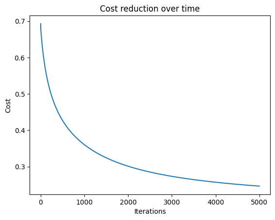

```python
### THIS IS THE ONLY CELL YOU MUST EDIT FOR PART-1

# train the logistic regression model

# initializae hyperparameters nepochs and alpha
nepochs = 5000
alpha = 2.5e-6

# initialize model parameters w and b
w = np.zeros((n,1))
b = 0

# this list will collect loss for each iteration
costs = []


# repeat for nepochs
### (2.1.1) YOUR CODE HERE
for epoch in range(nepochs):
    # Forward pass
    z = np.dot(X, w) + b
    yhat = 1 / (1 + np.exp(-z))

    # Calculate loss
    cost = -np.mean(y * np.log(yhat) + (1 - y) * np.log(1 - yhat))
    # costs.append(cost)

    # Backward propagation
    dz = yhat - y
    dw = np.dot(X.T, dz) / m
    db = np.mean(dz)

    # Gradient descent
    w -= alpha * dw
    b -= alpha * db


    # append loss to costs: This step is done to keep track of how the loss changes over the course of training
    # Costs: It is likely initialized as an empty list before the training loop. It is used to store the loss values at each iteration.
    ### (2.1.5) YOUR CODE HERE
    costs.append(cost)


# use final parameters w and b to calcualte accuracy for training data X, y
#  - do a single forward pass for X: calcualte z, yhat
#  - set yhat to round(yhat) (that is, thresholding binary classification prediction at 0.5)
#  - calcualte metrics.accuracy_score(y, yhat) and print it
### (2.1.6) YOUR CODE HERE
y_pred = 1 / (1 + np.exp(-(np.dot(X, w) + b)))
y_pred = np.round(y_pred)
accuracy = metrics.accuracy_score(y, y_pred)
print(f"Accuracy: {accuracy}")


# use plt.plot(costs)  to plot  costs against iterations and show the plot
### (2.1.7) YOUR CODE HERE

plt.plot(costs)
plt.xlabel('Iterations')
plt.ylabel('Cost')
plt.title('Cost reduction over time')
plt.show()
```

```python
### DO NOT EDIT THIS CELL!!!

# compare results from your implementation to that of SGDClassifier
# your accuracy score above should match (or be very close to) what you get from here

nepochs = 5000
alpha = 2.5e-6
y = y.reshape(y.shape[0],) # to avoid warning

from sklearn.linear_model import SGDClassifier
clf = SGDClassifier(loss='log', # loss function for logistic regression
                    penalty=None, alpha=0, # no regularization
                    max_iter=nepochs, tol=None, # stop based only on nepochs
                    shuffle=False, random_state=0, # don't shuffle, use random state to replicate results
                    learning_rate='constant', eta0=alpha) # constant learning rate of alpha
clf.fit(X,y)
print (round(clf.score(X,y),2))
```

```
0.92
```

### Part 2

- Linear Regression using the diabetes dataset
- We aren't going to preprocess data or split into train/test since the focus here is purely on the gradient descent algorithm
- NOTE: YOU WILL ONLY EDIT ONE CELL FOR PART-2 (SEE BELOW) (5% for each step, but 25% in total)

```
MSE: 2880.4940919140995
R^2: 0.5142411459934224
```

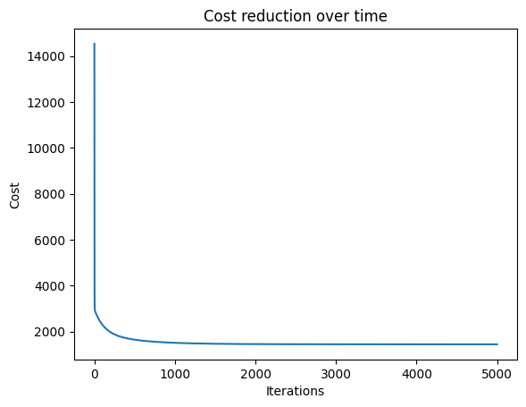

```python
### THIS IS THE ONLY CELL YOU MUST EDIT FOR PART-2
from sklearn.datasets import load_diabetes
# train the linear regression model
dataset = load_diabetes()
X = dataset.data
y = dataset.target.reshape(-1, 1)


n = X.shape[1]
# initialize hyperparameters nepochs and alpha
nepochs = 5000
alpha = 0.5

# initialize model paramters w and b
w = np.zeros((n,1))
b = 0

# this list will collect loss for each iteration
costs = []

# repeat for nepochs
### (2.2.1) YOUR CODE HERE
for epoch in range(nepochs):
    # Forward pass
    z = np.dot(X, w) + b
    yhat = z  # In linear regression, output is directly the linear combination

    # Calculate loss (Mean Squared Error)
    loss = np.mean((yhat - y) ** 2) / 2


    # Backward propagation
    dz = yhat - y
    dw = np.dot(X.T, dz) / len(y)
    db = np.mean(dz)

    # Gradient descent
    w -= alpha * dw
    b -= alpha * db


    # append loss to costs: This step is done to keep track of how the loss changes over the course of training
    # Costs: It is likely initialized as an empty list before the training loop. It is used to store the loss values at each iteration.
    ### (2.2.5) YOUR COD HERE
    costs.append(loss)


# use final parameters w and b to calcualte mse and r2 for training data X, y
#  - do a single forward pass for X: calcualte z, yhat
#  - calculate metrics.mean_squared_error(y, yhat) and print it
#  - calculate metrics.r2_score(y, yhat) and print it
### (2.2.6) YOUR CODE HERE
y_pred = np.dot(X, w) + b
mse = metrics.mean_squared_error(y, y_pred)
r2 = metrics.r2_score(y, y_pred)

print(f"MSE: {mse}")
print(f"R^2: {r2}")



# use plt.plot(costs) to plot costs against iterations and show the plot
### (2.2.7) YOUR CODE HERE
# Plot costs against iterations
plt.plot(costs)
plt.xlabel('Iterations')
plt.ylabel('Cost')
plt.title('Cost reduction over time')
plt.show()
```

```python
### DO NOT EDIT THIS CELL!!!

# compare results from our implementation to that of SGDRegressor
# your mse and r2 score above should match (or be very close to) what you get from here

nepochs = 5000
alpha = 0.5
y = y.reshape(y.shape[0],) # to avoid warning

from sklearn.linear_model import SGDRegressor
clf = SGDRegressor(loss='squared_error', # mse for linear regression
                    penalty=None, alpha=0, # no regularization
                    max_iter=nepochs, tol=None, # stop based on only on nepochs
                    shuffle=False, random_state=0, # don't shuffle, use random state to replicate results
                    learning_rate='constant', eta0=alpha) # constant learning rate of alpha
clf.fit(X,y)
yhat = clf.predict(X)
print (round(metrics.mean_squared_error(y, yhat),2))
print (round(clf.score(X,y),2))
```

```
2922.89
0.51
```

I ackowledge that I have used Chagpt4

## Acknowledgment

Acknowledge here if you have used any GenAI tools in this assignment and anyone you have worked together with on this assignment. (5%)

```python
!pip install jupyter
!pip install nbconvert
```

```python
from google.colab import drive
drive.mount('/content/drive',force_remount=True)
```

```python
!jupyter nbconvert --to html "/content/drive/MyDrive/Quater 3/Analytics unstructured data/LA4_JainGarvita.ipynb"
```

```
[NbConvertApp] Converting notebook /content/drive/MyDrive/Quater 3/Analytics unstructured data/LA4_JainGarvita.ipynb to html
[NbConvertApp] Writing 717068 bytes to /content/drive/MyDrive/Quater 3/Analytics unstructured data/LA4_JainGarvita.html
```